# Tugas Praktikum 5

Kaylila Kireinahana

2023-09-26

```r
library(ggplot2)
library(tsibble)
library(tseries)
library(MASS)
library(rio)
```

# Impor Data

```r
data_mpdw <- import("https://raw.githubusercontent.com/reiflection/MPDW/main/Data/Cerial%20Prices.csv")
set.seed(1070)
rice <- ts(data_mpdw$Price_rice_ton)
str(rice)
```

```
##  Time-Series [1:360] from 1 to 360: 278 277 278 274 269 ...
```

# Tidak Stasioner dalam Rataan dan Ragam

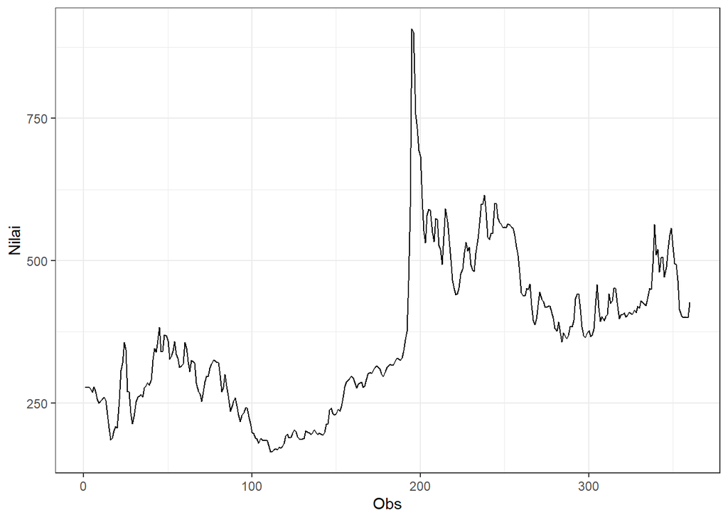

```
## [1] 364.1056
```

## Plot ACF

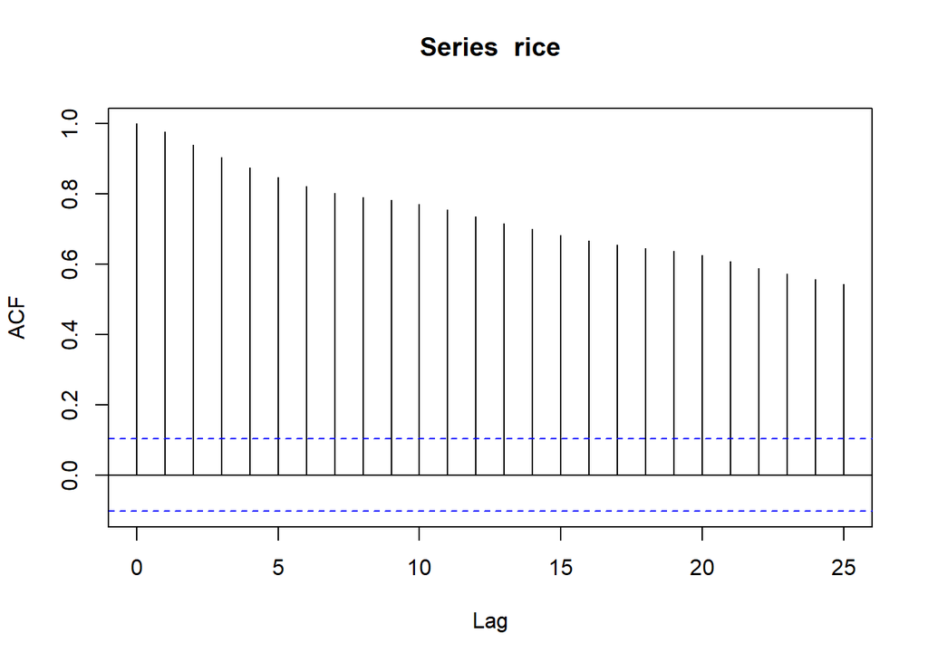

```r
acf(rice)
```

Dari hasil diatas, ACF cenderung menurun secara perlahan (tails off). Hal ini menunjukkan bahwa data bukan stasioner.

## Uji ADF

```r
tseries::adf.test(rice)
```

```
##
##  Augmented Dickey-Fuller Test
##
## data:  rice
## Dickey-Fuller = -2.1458, Lag order = 7, p-value = 0.5154
## alternative hypothesis: stationary
```

H0: Data tidak stasioner dalam rataan

H1: Data stasioner dalam rataan

Berdasarkan uji ADF tersebut, p-value sebesar 0.5154 yang lebih besar dari taraf 5%. Hal ini menunjukkan bahwa data tidak stasioner dalam rataan.

## Plot Box-Cox

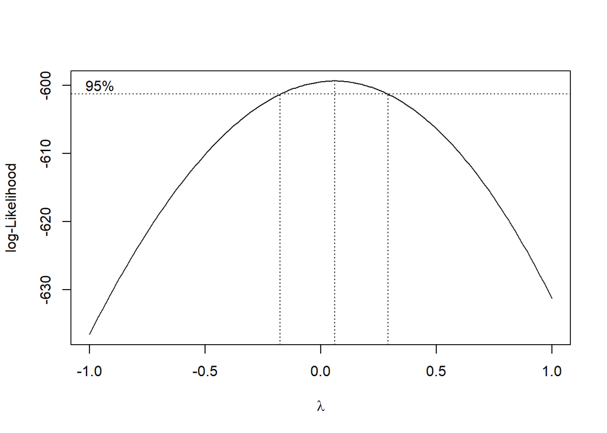

```r
rice.index <- seq(1:360)
rice.bc = boxcox(rice ~ rice.index, lambda = seq(-1,1,by=0.01))
```

```r
#Nilai Rounded Lambda
rice.lambda <- rice.bc$x[which.max(rice.bc$y)]
rice.lambda
```

```
## [1] 0.06
```

```r
#SK
rice.bc$x[rice.bc$y > max(rice.bc$y) - 1/2 * qchisq(.95,1)]
```

```
##  [1] -0.17 -0.16 -0.15 -0.14 -0.13 -0.12 -0.11 -0.10 -0.09 -0.08 -0.07 -0.06
## [13] -0.05 -0.04 -0.03 -0.02 -0.01  0.00  0.01  0.02  0.03  0.04  0.05  0.06
## [25]  0.07  0.08  0.09  0.10  0.11  0.12  0.13  0.14  0.15  0.16  0.17  0.18
## [37]  0.19  0.20  0.21  0.22  0.23  0.24  0.25  0.26  0.27  0.28  0.29
```

Gambar diatas menunjukkan bahwa nilai rounded value yang optimum sebesar 0.06 dengan selang bawah -0.17 dan selang atas 0.29. Selang tersebut tidak memuat nilai satu sehingga data tidak stasioner dalam ragam.

## Partisi Data

### Bagian 1 (Tidak Stasioner dalam Rataan, Stasioner dalam Ragam)

```r
rice.dt1 <- rice[1:121] |> ts()
mean(rice.dt1)
```

```
## [1] 264.9451
```

```r
var(rice.dt1)
```

```
## [1] 3361.606
```

#### Plot Time Series

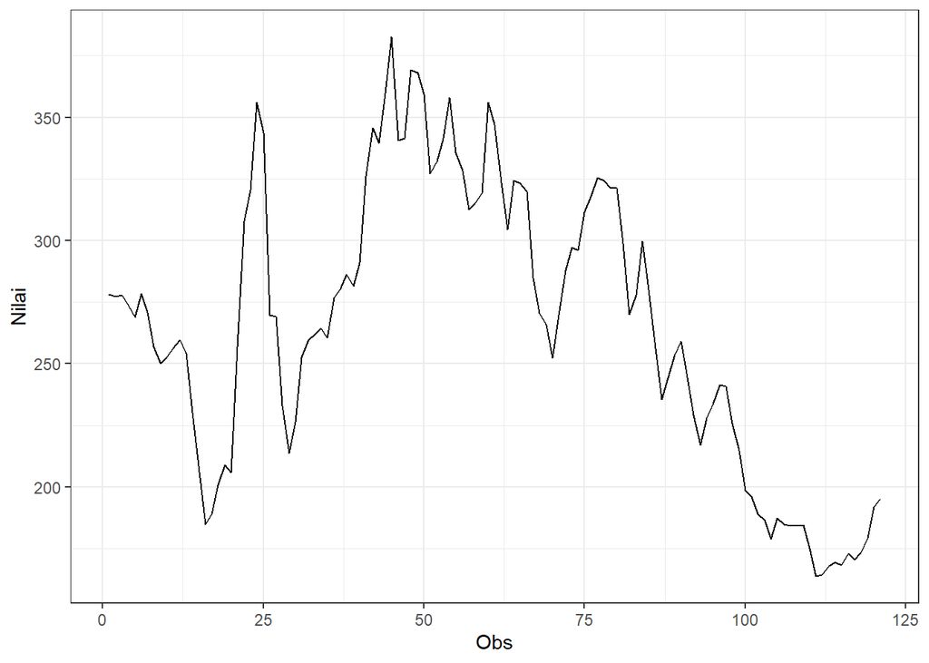

```r
rice.dt1 |> as_tsibble() |>
  ggplot(aes(x = index, y = value)) +
  geom_line() + theme_bw() +
  xlab("Obs") + ylab("Nilai")
```

Plot diatas menunjukkan adanya pola tren.

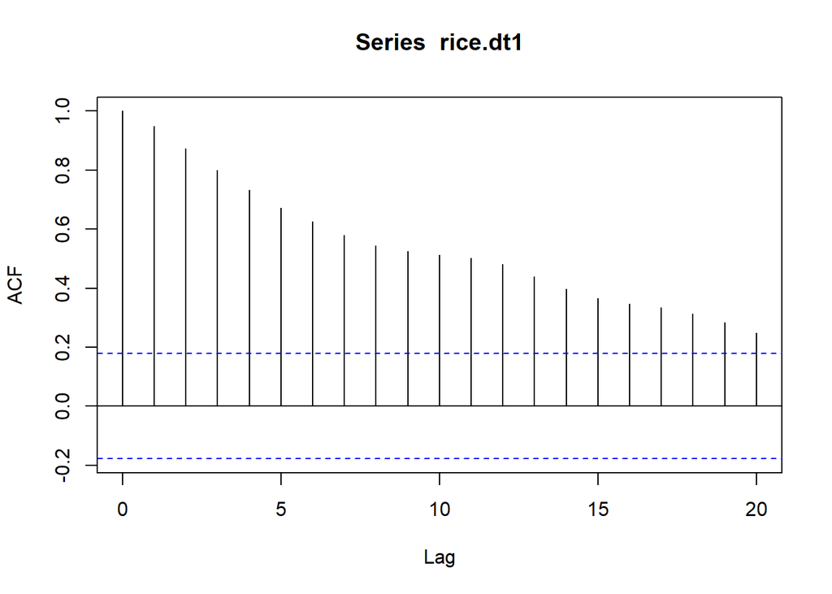

```r
acf(rice.dt1)
```

plot ACF pada gambar tersebut secara perlahan menuju nilai nol.

#### Uji ADF

```r
tseries::adf.test(rice.dt1)
```

```
##
##  Augmented Dickey-Fuller Test
##
## data:  rice.dt1
## Dickey-Fuller = -1.9743, Lag order = 4, p-value = 0.5872
## alternative hypothesis: stationary
```

Berdasarkan uji tersebut, p-value lebih besar dari taraf 5% yang menunjukkan bahwa data tidak stasioner dalam rataan.

#### Plot Box-Cox

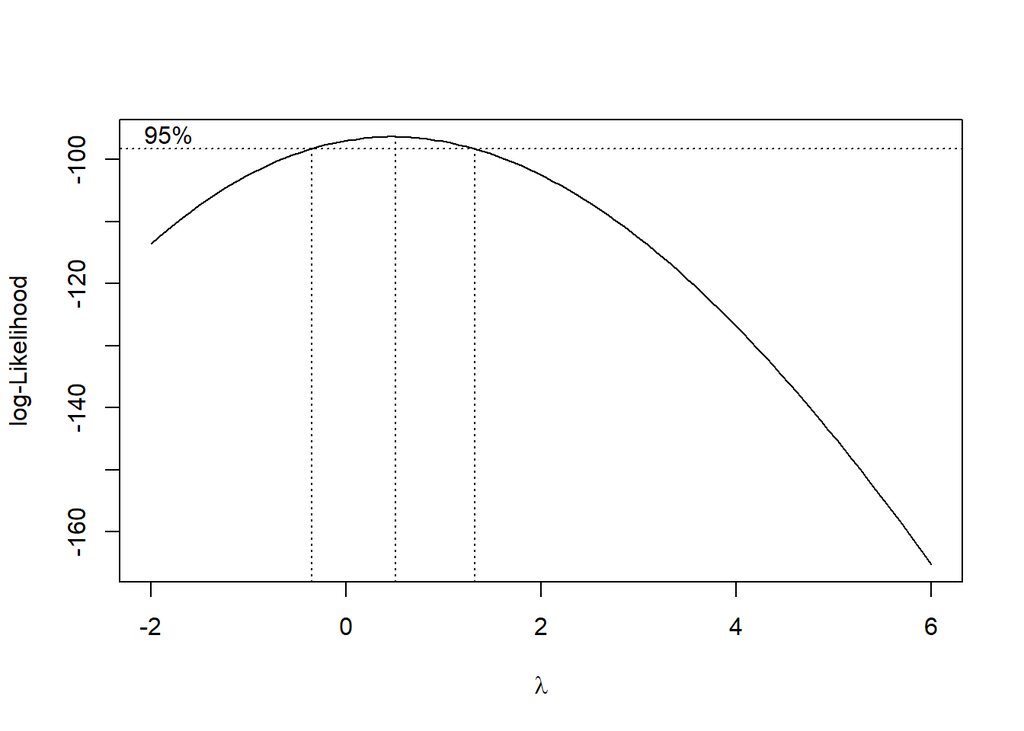

```r
rice.index1 <- seq(1:121)
rice.bc1 = boxcox(rice.dt1 ~ rice.index1, lambda = seq(-2,6,by=1))
```

```r
#Nilai Rounded Lambda
rice.lambda1 <- rice.bc1$x[which.max(rice.bc1$y)]
rice.lambda1
```

```
## [1] 0.5050505
```

```r
#SK
rice.bc1$x[rice.bc1$y > max(rice.bc1$y) - 1/2 * qchisq(.95,1)]
```

```
##  [1] -0.30303030 -0.22222222 -0.14141414 -0.06060606  0.02020202  0.10101010
##  [7]  0.18181818  0.26262626  0.34343434  0.42424242  0.50505051  0.58585859
## [13]  0.66666667  0.74747475  0.82828283  0.90909091  0.98989899  1.07070707
## [19]  1.15151515  1.23232323  1.31313131
```

### Bagian 2 (Tidak Stasioner dalam Rataan dan Ragam)

```r
rice.dt2 <- rice[1:241] |> ts()
mean(rice.dt2)
```

```
## [1] 324.2034
```

```r
var(rice.dt2)
```

```
## [1] 19031.75
```

#### Uji ADF

```r
tseries::adf.test(rice.dt2)
```

```
##
##  Augmented Dickey-Fuller Test
##
## data:  rice.dt2
## Dickey-Fuller = -2.0663, Lag order = 6, p-value = 0.548
## alternative hypothesis: stationary
```

#### Plot Box-Cox

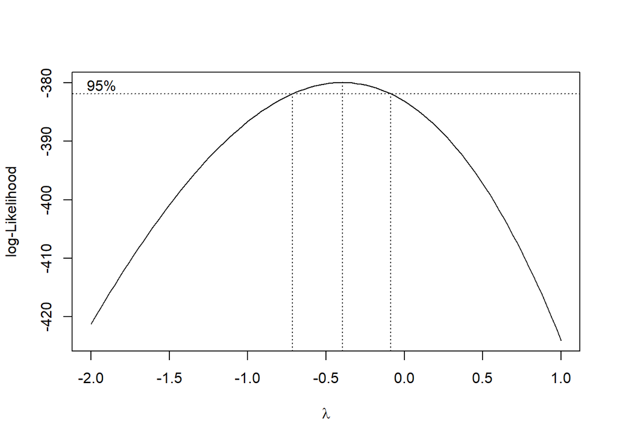

```r
rice.index2 <- seq(1:241)
rice.bc2 = boxcox(rice.dt2 ~ rice.index2, lambda = seq(-2,1,by=1))
```

```r
#Nilai Rounded Lambda
rice.lambda2 <- rice.bc2$x[which.max(rice.bc2$y)]
rice.lambda2
```

```
## [1] -0.3939394
```

```r
#SK
rice.bc2$x[rice.bc2$y > max(rice.bc2$y) - 1/2 * qchisq(.95,1)]
```

```
##  [1] -0.69696970 -0.66666667 -0.63636364 -0.60606061 -0.57575758 -0.54545455
##  [7] -0.51515152 -0.48484848 -0.45454545 -0.42424242 -0.39393939 -0.36363636
## [13] -0.33333333 -0.30303030 -0.27272727 -0.24242424 -0.21212121 -0.18181818
## [19] -0.15151515 -0.12121212 -0.09090909
```

Berdasarkan output diatas, nilai optimum yang diperoleh adalah sebesar -0.3939394 dengan batas bawah -0.69696970 dan batas atas -0.09090909. Karena selang kepercayaan tidak melewati satu, maka partisi data 2 tidak stasioner dalam ragam.